# Inferência parte 1

Nazareno

## Os dados

```r
lastfm = read_csv(here("dados/experimento-lastfm.csv"),
                  col_types = cols(.default = col_double(),
                                   user = col_character()))
glimpse(lastfm)
```

```
Observations: 11,989
Variables: 15
$ user           <chr> "00blixt", "0ctane", "0sebastian0", "0xkirill", "111ArcherAvenue", "1900lazio", "1Ferdi", "1gOR", "1uLyMaN", "200iso", "20lbcat", "23EmCia", "280890", "286", "2la_sCak...
$ ecletic        <dbl> 1159.4960, 3439.8373, 1611.4464, 697.0974, 1660.1563, 1907.9026, 2893.5756, 3399.6327, 1443.3051, 3229.4767, 3260.3796, 662.1902, 1876.0193, 4254.5319, 1296.4740, 1507...
$ clusters_total <dbl> 37, 155, 68, 37, 72, 93, 163, 150, 88, 132, 130, 24, 78, 213, 47, 61, 32, 59, 47, 171, 79, 145, 103, 83, 164, 56, 47, 92, 79, 155, 38, 146, 67, 87, 31, 120, 59, 42, 99...
$ clusters       <dbl> 19, 57, 25, 13, 31, 37, 64, 59, 27, 58, 62, 12, 36, 73, 24, 25, 18, 24, 22, 85, 30, 64, 41, 28, 72, 19, 27, 41, 34, 72, 23, 59, 19, 42, 10, 58, 33, 19, 58, 13, 28, 35,...
$ media_pop      <dbl> 5.536362, 4.726167, 5.804086, 4.997963, 5.800357, 4.409396, 5.166950, 4.566471, 5.121150, 5.359932, 5.401431, 5.892907, 5.940770, 5.037179, 5.792412, 5.734491, 5.03960...
$ mediana_pop    <dbl> 5.660406, 4.730935, 5.896073, 5.214290, 5.865121, 4.363506, 5.211733, 4.606261, 5.183148, 5.501684, 5.632448, 6.191716, 6.093232, 5.281534, 5.979367, 6.053155, 5.12848...
$ dp_pop         <dbl> 0.6852190, 0.8819529, 0.6167104, 0.8685811, 0.5448580, 0.8286681, 0.7797182, 0.8767425, 0.8090134, 0.8125588, 0.9143137, 0.7075437, 0.5407531, 0.9885084, 0.5657392, 0....
$ news           <dbl> 38, 32, 24, 36, 28, 25, 30, 28, 14, 22, 27, 21, 23, 37, 25, 30, 15, 40, 15, 24, 39, 54, 20, 16, 34, 21, 29, 78, 14, 44, 55, 29, 24, 64, 12, 37, 62, 37, 72, 18, 34, 32,...
$ news_total     <dbl> 38, 32, 24, 36, 28, 25, 30, 28, 14, 22, 27, 21, 23, 37, 25, 30, 15, 40, 15, 24, 43, 55, 20, 16, 34, 21, 29, 79, 14, 44, 55, 29, 24, 64, 12, 37, 62, 38, 76, 18, 35, 33,...
$ old            <dbl> 116, 130, 10, 46, 128, 95, 228, 53, 46, 118, 90, 34, 100, 109, 103, 96, 76, 119, 66, 52, 40, 145, 78, 133, 145, 39, 171, 191, 150, 284, 94, 178, 75, 98, 64, 69, 227, 1...
$ old_total      <dbl> 119, 141, 13, 71, 133, 167, 256, 63, 52, 125, 102, 45, 111, 114, 112, 113, 79, 129, 68, 56, 82, 164, 81, 157, 158, 40, 182, 230, 159, 297, 98, 213, 94, 122, 68, 72, 26...
$ count_sim      <dbl> 0.155514371, 0.074823398, -0.123188406, 0.084193831, 0.037334528, 0.153333333, -0.006896552, 0.287238106, -0.164835165, 0.134199134, 0.040057594, 0.052506116, 0.204000...
$ tempo_sim      <dbl> 0.208395596, -0.020325875, -0.043478261, -0.001606542, 0.163103936, -0.020134682, 0.069204567, 0.178913021, -0.033335391, 0.183818442, -0.111653687, 0.386514024, 0.326...
$ count_pop      <dbl> 0.269231042, 0.131446510, -0.166666667, 0.093725208, 0.095238095, 0.086666667, 0.020689655, -0.085107587, -0.076923077, -0.030303030, 0.211732994, -0.186158048, 0.2147...
$ tempo_pop      <dbl> 0.083036798, -0.142281125, -0.115942029, 0.130129927, 0.090185994, -0.053692484, 0.212227337, 0.098802713, -0.033335391, -0.035013037, 0.329084551, 0.019325701, 0.3596...
```

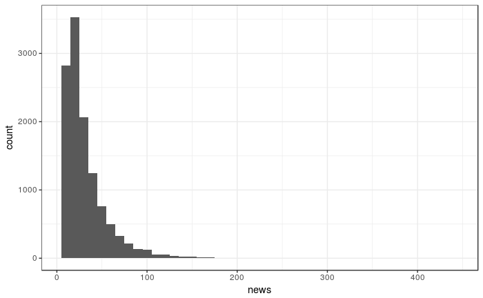

```r
lastfm = select(lastfm, news, ecletic)
lastfm %>% ggplot(aes(news)) + geom_histogram(binwidth = 10)
```

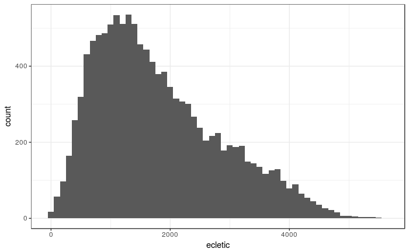

```r
lastfm %>% ggplot(aes(ecletic)) + geom_histogram(binwidth = 100)
```

## Amostra e visões a partir dela

Imagine por agora que os dados que temos do Last.fm são completos. Que são a população inteira de usuários. Como seria nossa visão dos dados se tivéssemos apenas uma amostra dos dados? `sample(x, n)` faz uma amostra aleatórioa de `n` elementos tirados do vetor `x`:

Se calcularmos a média do números de novos artistas escutados para três amostras de 100 elementos, teremos 3 resultados diferentes:

```r
sample(lastfm$news, 100) %>% mean()
```

```
[1] 32.3
```

```r
sample(lastfm$news, 100) %>% mean()
```

```
[1] 26.03
```

```r
sample(lastfm$news, 100) %>% mean()
```

```
[1] 35.2
```

Se fizermos isso muitas vezes podemos ver como essa variação acontece. A distribuição dos valores de uma estatística em diferentes amostras de uma população se chama **distribuição amostral** da estatística.

```r
set.seed(1)
amostras = data.frame(amostra = 1:1000) %>% # faremos 1000 vezes
  mutate(media = map_dbl(amostra, ~ lastfm %>%
                                      pull(news) %>%
                                      sample(100) %>%
                                      mean()))
amostras
```

| amostra | media |
| --- | --- |
| 1 | 34.92 |
| 2 | 32.95 |
| 3 | 31.83 |
| 4 | 35.94 |
| 5 | 33.71 |
| 6 | 31.73 |
| 7 | 32.89 |
| 8 | 32.26 |
| 9 | 32.65 |
| 10 | 32.10 |

[output cut: 990 more lines]

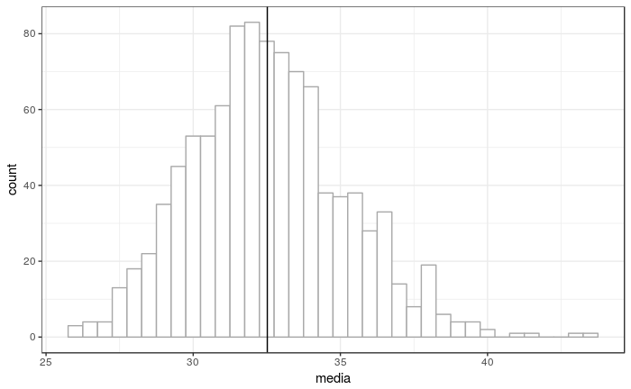

```r
amostras %>%
  ggplot(aes(media)) +
  geom_histogram(binwidth = .5, fill = "white", colour = "darkgrey") +
  geom_vline(xintercept = mean(lastfm$news)) # média calculada com todos os dados
```

E se o tamanho da amostra (*n*) fosse muito menor?

```r
amostras = data.frame(amostra = 1:1000) %>% # faremos 1000 vezes
  mutate(media = map_dbl(amostra, ~ lastfm %>%
                                      pull(news) %>%
                                      sample(10) %>%
                                      mean()))
amostras
```

| amostra | media |
| --- | --- |
| 1 | 28.9 |
| 2 | 51.6 |
| 3 | 29.1 |
| 4 | 24.7 |
| 5 | 55.6 |
| 6 | 31.8 |
| 7 | 31.0 |
| 8 | 31.6 |
| 9 | 28.9 |
| 10 | 34.3 |

[output cut: 990 more lines]

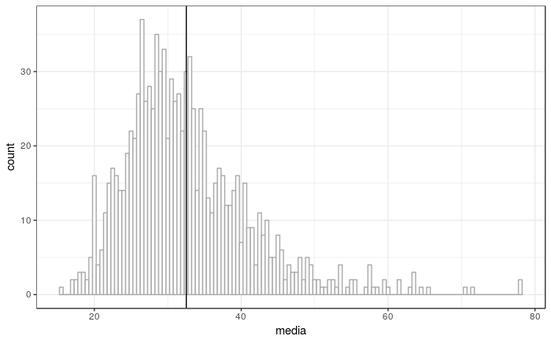

```r
amostras %>%
  ggplot(aes(media)) +
  geom_histogram(binwidth = .5, fill = "white", colour = "darkgrey") +
  geom_vline(xintercept = mean(lastfm$news)) # média calculada com todos os dados
```

A mesma lógica vale para outras estatísticas além da média. O código abaixo analisa a distribuição dos valores observados em amostras a partir das quais calculamos a *mediana*. Altere o código para usar outra estatística: (dica: max e min não funcionam.)

```r
amostras = data.frame(amostra = 1:1000) %>% # faremos 1000 vezes
  mutate(estatistica = map_dbl(amostra, ~ lastfm %>%
                                      pull(news) %>%
                                      sample(100) %>%
                                      median()))
amostras
```

| amostra | estatistica |
| --- | --- |
| 1 | 28.0 |
| 2 | 24.5 |
| 3 | 25.0 |
| 4 | 27.0 |
| 5 | 23.5 |
| 6 | 22.0 |
| 7 | 21.5 |
| 8 | 22.5 |
| 9 | 26.0 |
| 10 | 24.0 |

[output cut: 990 more lines]

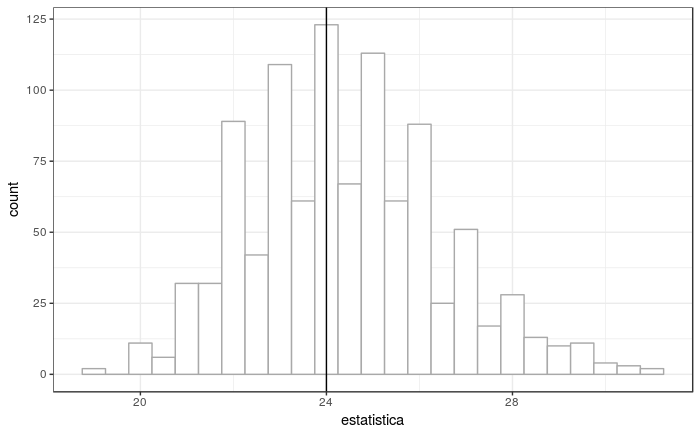

```r
amostras %>%
  ggplot(aes(estatistica)) +
  geom_histogram(binwidth = .5, fill = "white", colour = "darkgrey") +
  geom_vline(xintercept = median(lastfm$news)) # média calculada com todos os dados
```

## Distribuição amostral

A distribuição dos valores de uma estatística a partir de amostras é chamada de *distribuição amostral* daquela estatística. Ela tem um papel importante, porque é a partir do entendimento dela que estimaremos quanta confiança temos em uma estatística que estamos calculando a partir de uma amostra.

O principal a entender aqui é que se conhecermos a distribuição amostral, saberemos quão longe normalmente a estatística calculada para uma amostra está daquela calculada para a população. Sabendo isso, podemos calcular uma margem de erro para a estimativa feita a partir da amostra.

## A situação mais comum na vida real

Normalmente temos *uma amostra* da população apenas. Daí não conhecemos a distribuição amostral. Mas gostaríamos de a partir da nossa amostra estimar onde está a estatística para a população.

Exemplo: queremos estimar qual a proporção de pessoas que gostará do produto (a estatística) entre todos os usuários (a população) a partir do cálculo da proporção de pessoas que gostou do produto (a mesma estatística) em um teste com 100 pessoas (a amostra).

Repare que se conhecermos como a estatística varia na distribuição amostral (ex: 2 pontos pra mais ou pra menos cobrem 99% dos casos) e temos a estatística calculada para a amostra, poderíamos estimar uma faixa de valores onde achamos que a estatística está para a população *com 99% de confiança*.

### A ideia central que usaremos

Não temos a população, para estimar a variação na distribuição amostral. A ideia principal que usaremos, em uma técnica chamada *boostrapping* é que *usar a amostra como substituto da população e simular a amostragem através de reamostragem com reposição fornece uma estimativa precisa da variação na distribuição amostral*.

Pegando por partes:

- Consideramos a amostra $A$ que tem tamanho $n$ como sendo um substituto da população
- Repetimos $b$ vezes o seguinte processo: criamos uma amostra de tamanho $n$ obtendo elementos aleatoriamente de $A$, repondo cada elemento depois de cada sorteio.
- Calculamos a estatística $e$ que nos interessa (média, mediana, desvio padrão, o que for) para cada uma das $b$ amostras.

Como resultado, sabemos como a estatística $e$ varia em uma simulação de $b$ amostragens.

A partir dessa informação, podemos estimar quão longe no máximo a estatística $e_a$ que calculamos para nossa amostra está da estatística $e_p$ para a população. Isso porque se sabemos normalmente quão longe $e_a$ está de $e_p$ (que é o que estimamos com o boostrap), sabemos também o inverso.

Assim, se estimamos que em 99% das amostras, $e_a$ está a +/- 10 unidades de $e_p$, e calculamos que $e_a = 22$, podemos estimar que *com 99% de confiança* $e_p$ está em $e_a +/ - 10 = [12, 32]$.

### Aplicando bootstrapping

```r
summary(experimentos)
```

[output not shown]

```
       i          media_exp
 Min.   :   1   Min.   :25.43
 1st Qu.:1001   1st Qu.:30.80
 Median :2000   Median :32.06
 Mean   :2000   Mean   :32.16
 3rd Qu.:3000   3rd Qu.:33.43
 Max.   :4000   Max.   :39.59
```

Calculando o IC:

```r
# IC com 90%:
alpha = .1
quantile(experimentos$media_exp,
         probs = c(.05, .95))
```

```
      5%      95%
29.11500 35.39025
```

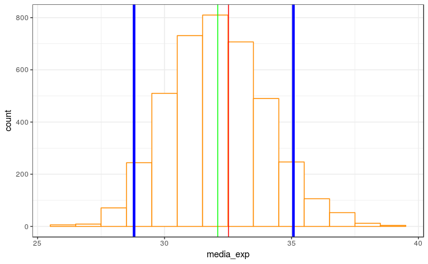

```r
cis = experimentos %>%
    mutate(diferenca = media_exp - media_amostra) %>%
    summarise(l = quantile(diferenca, alpha/2),
              u = quantile(diferenca, 1 - alpha/2)) %>%
    mutate(ci_lower = media_amostra - u,
           ci_upper = media_amostra - l)
ggplot(experimentos, aes(x = media_exp)) +
  geom_histogram(binwidth = 1, colour = "darkorange", fill = "white") +
  geom_vline(aes(xintercept = cis$ci_lower), colour = "blue", size = 1.5) +
  geom_vline(aes(xintercept = cis$ci_upper), colour = "blue", size = 1.5) +
  geom_vline(aes(xintercept = media_amostra), colour = "green") +
    geom_vline(aes(xintercept = mean(lastfm$news)), colour = "red")
```

Com outro nível de confiança:

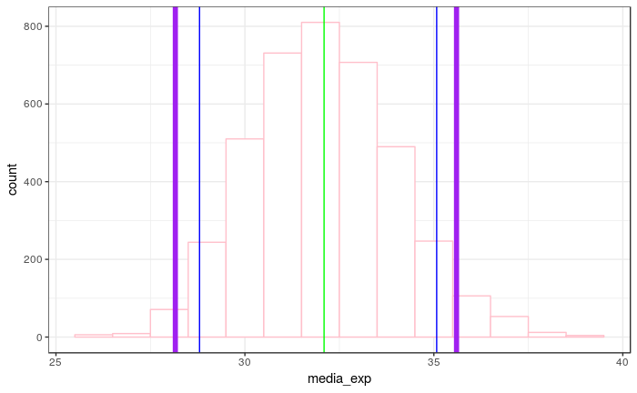

```r
# IC com 95%:
alpha2 = .05
cis2 = experimentos %>%
    mutate(diferenca = media_exp - media_amostra) %>%
    summarise(l = quantile(diferenca, alpha2/2),
              u = quantile(diferenca, 1 - alpha2/2)) %>%
    mutate(ci_lower = media_amostra - u,
           ci_upper = media_amostra - l)
ggplot(experimentos, aes(x = media_exp)) +
  geom_histogram(binwidth = 1, colour = "pink", fill = "white") +
    geom_vline(aes(xintercept = cis$ci_lower), colour = "blue") +
  geom_vline(aes(xintercept = cis$ci_upper), colour = "blue") +
  geom_vline(aes(xintercept = cis2$ci_lower), colour = "purple", size = 2) +
  geom_vline(aes(xintercept = cis2$ci_upper), colour = "purple", size = 2) +
  geom_vline(aes(xintercept = media_amostra), colour = "green")
```